# Análise de Dados em R - Aula 2

# **Manipulação de Dados**

Nesta aula vamos avançar um pouco mais na manipulação e visualização de dados e também executar alguns cálculos estatísticos. O primeiro banco de dados que iremos trabalhar é o [AtlasBrasil](https://github.com/claudioalvesmonteiro/aulas_analisededados/blob/master/Dados/AtlasBrasil_Consulta.csv). Entre no repositório e selecione *Raw*, depois clique com o botão direito do mouse na página, selecione *salvar como* e salve o banco na sua pasta de trabalho.

Com base no que você já aprendeu, importe o banco de dados no R a partir da linha de comando.

```r
atlas_brasil <- read.csv("dados/AtlasBrasil_Consulta.csv", stringsAsFactors = F)
```

**Atenção!** Lembre-se de que uma das maiores funcionalidades do R é a replicabilidade das análises. Assim, devemos deixar os códigos salvos em um script que siga uma execução eficiente.

#### Exercício

Depois de carregar o banco, visualize-o e tente identificar um erro nos casos da tabela. Após identificado, corrija-o com base no que você já aprendeu nas aulas anteriores.

### Pacote *stringr*

Outro problema no banco é na variável “IDHM”, que está com a decimal demilitada por “,” em vez de “.” (padrão de decimal usado no R). Se pedirmos para o R nos retornar a classe desta variável podemos ver que ela é da classe *character*. Para trabalharmos com ela vamos substituir a “,” pelo “.” e para tal utilizaremos o pacote *stringr*.

```r
# classe da variavel IDHM
class(atlas_brasil$IDHM.2010)
```

```
[1] "character"
```

```r
# instalar e carregar pacote stringr
install.packages("stringr", dependencies = T)
library(stringr)
```

```r
# vamos primeiro olhar a documentacao da funcao 'str_replace'
`?`(str_replace)

# substituir ',' por '.'
atlas_brasil$IDHM.2010 <- str_replace(atlas_brasil$IDHM.2010, ",", ".")

# classe da variavel
class(atlas_brasil$IDHM.2010)
```

```
[1] "character"
```

#### Exercício

Ao pedir a classe da variável é possível observar que ela ainda permanece como *character*. Transforme-a em numérica com base no que você já aprendeu.

Outra funcionalidade interessante do pacote *stringr* é que podemos detectar casos em uma variável que possuem um padrão específico de letras. Podemos observar na variavel “Espacialidades” que a sigla do estado de cada munícipio está na mesma coluna que o nome do mesmo:

```r
head(atlas_brasil$Espacialidades, 20)
```

```
 [1] "Brasil"                   "Abadia de Goiás (GO)"
 [3] "Abadia dos Dourados (MG)" "Abadiânia (GO)"
 [5] "Abaeté (MG)"              "Abaetetuba (PA)"
 [7] "Abaiara (CE)"             "Abaíra (BA)"
 [9] "Abaré (BA)"               "Abatiá (PR)"
[11] "Abdon Batista (SC)"       "Abelardo Luz (SC)"
[13] "Abel Figueiredo (PA)"     "Abre Campo (MG)"
[15] "Abreu E Lima (PE)"        "Abreulândia (TO)"
[17] "Acaiaca (MG)"             "Açailândia (MA)"
[19] "Acajutiba (BA)"           "Acará (PA)"
```

Para exemplificiar, podemos criar uma variável no banco que nos informará se a cidade é do Estado de Pernambuco com base na funcao *str_detect*:

```r
# detectar o padrao 'PE' na variavel 'Espacialidades' e atribuir o resultado
# a uma nova variavel
atlas_brasil$pernambuco <- str_detect(atlas_brasil$Espacialidades, "(PE)")

# agora podemos criar uma nova base de dados apenas com os casos de PE
atlas_pe <- atlas_brasil[atlas_brasil$pernambuco == TRUE, ]
```

# **Estatísticas Descritivas**

Agora iremos executar algumas estatísticas descritivas para a variável “IDHM”, no nosso banco “atlas_pe”:

```r
# calcular media
mean(atlas_pe$IDHM.2010)
```

```
[1] 0.5962486
```

```r
# mediana
median(atlas_pe$IDHM.2010)
```

```
[1] 0.593
```

```r
# desvio-padrao
sd(atlas_pe$IDHM.2010)
```

```
[1] 0.04751456
```

```r
# funcao summary
summary(atlas_pe$IDHM.2010)
```

```
   Min. 1st Qu.  Median    Mean 3rd Qu.    Max.
 0.4870  0.5670  0.5930  0.5962  0.6130  0.7880
```

# **Gráficos Descritivos**

### Histograma e densidade

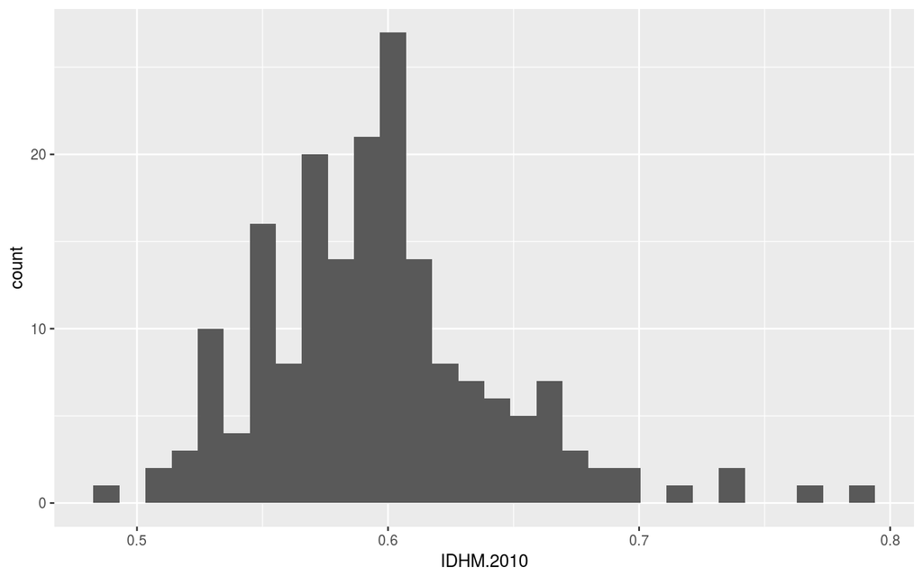

```r
# carregue o pacote ggplot2
library(ggplot2)

# executar histograma IDHM para Pernambuco
ggplot(data = atlas_pe, aes(x = IDHM.2010)) + geom_histogram()
```

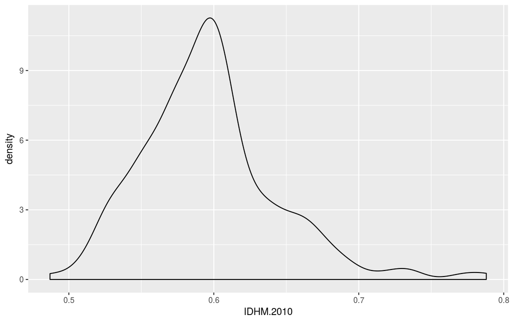

```r
# executar densidade IDHM para Pernambuco
ggplot(data = atlas_pe, aes(x = IDHM.2010)) + geom_density()
```

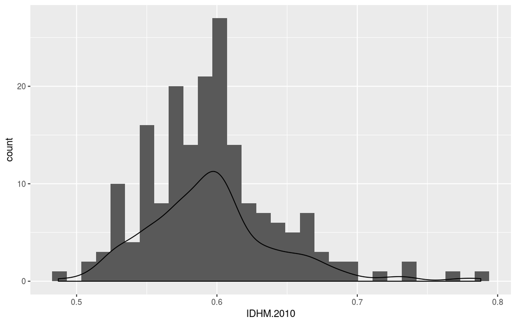

```r
# executar ambos no mesmo grafico
ggplot(data = atlas_pe, aes(x = IDHM.2010)) + geom_histogram() + geom_density()
```

### Boxplot

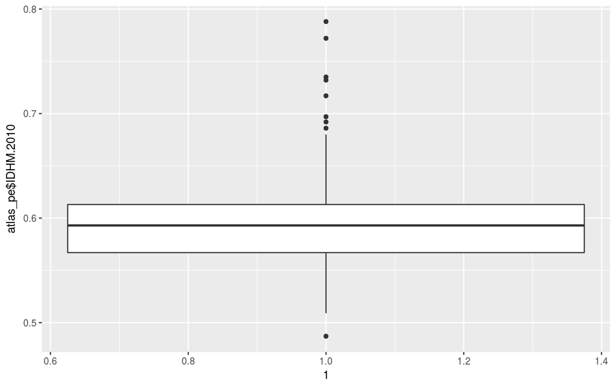

```r
# executar boxplot
ggplot(atlas_pe) + geom_boxplot(aes(y = atlas_pe$IDHM.2010, x = 1))
```

#### Exercício

Uma das principais questões envolvendo o aprendizado do R é a capacidade de encontrar resoluções para procedimentos no R na internet, pois o R detém uma série de comunidades, blogs e forúns online, o que facilita esse processo. Para exemplificar isso faça o seguinte: (1) procure na internet como alterar o título dos eixos X e Y num gráfico *ggplot*; e (2) procure como alterar a cor de fundo do gráfico.

```r
## ALTERE OS TITULOS DOS EIXOS X E Y NO GRAFICO ABAIXO, NO SEU SCRIPT
ggplot(atlas_pe) + geom_boxplot(aes(y = atlas_pe$IDHM.2010, x = 1))

## ALTERE A COR DE FUNDO NO GRAFICO ABAIXO, NO SEU SCRIPT
ggplot(atlas_pe) + geom_boxplot(aes(y = atlas_pe$IDHM.2010, x = 1))
```

Cláudio A. Monteiro

Fevereiro, 2018